# HBCD Quality Control Documentation HBCD Genomics

Author

MIDB Analytics Hub and UMN GDC Working Group

# Genomics

This section outlines the standard procedures for the genomic data processing pipeline.

## Standard Procedure

### Module 1: Crossmap (optional)

CrossMap converts genome coordinates and annotation files between different reference assemblies. It supports a wide array of file formats, including BAM, CRAM, SAM, VCF, Wiggle, BigWig, BED, GFF, and GTF. For the purposes of our pipeline we will make use of PLINK Binary format and convert the genome build to GRCh38 (default: GRCh37 to GRCh38).

- **Flag:** `--use_crossmap` (Default: `1`)
- **Override:** Set to `0` if the build is already GRCh38.

### Module 2: GenotypeHarmonizer (optional)

GenotypeHarmonizer integrates genetic data by resolving inconsistencies in genomic strand and file format. It aligns study datasets to a specified reference genome and uses linkage disequilibrium (LD) to solve unknown or ambiguous strand issues and SNPs. We use it in our pipeline to align sample data to the GRCh38 reference genome using the reference file `ALL.hgdp1kg.filtered.SNV_INDEL.38.phased.shapeit5.vcf`.

- **Flag:** `--use_genome_harmonizer` (Default: `1`)
- **Override:** Set to `0` if the build is already harmonized.

### Module 3: Initial QC

Performs Quality Control prior to relatedness checks.

- Exclude SNPs and individuals with >10% missingness (**Plink**)
- Exclude SNPs and individuals with >2% missingness (**Plink**)

### Module 4: Relatedness

This module uses **KING** to separate related and unrelated study samples. The module also performs **PC-AiR** and **PC-Relate** for kinship estimation.

**KING** is a toolset that makes use of SNP data to identify how closely two individuals are related based on their DNA. This inference is based on the **kinship coefficient** ($ϕ$).

The fundamental equation KING uses to estimate the kinship coefficient $ϕ$ between individuals $i$ and $j$ is:

$$ϕij=NAa,Aa−2NAA,aaNAa,i+NAa,j$$

Based on the calculated $ϕ$, relationships are categorized as follows:

| Relationship Degree | Kinship Coefficient ($ϕ$) | Examples |
| --- | --- | --- |
| **Duplicate/Twin** | > 0.354 | Identical twins, same person sampled |
| **1st-Degree** | [0.177, 0.354] | Parent-Offspring, Full Siblings |
| **2nd-Degree** | [0.0884, 0.177] | Grandparent-Grandchild, Half-siblings |
| **Unrelated** | < 0.0442 | No close detectable relation |

**PC-AiR** performs Principal Component Analysis (PCA) for population structure detection while accounting for known or cryptic relatedness. It identifies a subset of unrelated individuals that represent the ancestral diversity of the sample to compute the principal components (PCs).

**PC-Relate** uses the principal components from PC-AiR to estimate kinship coefficients and IBS sharing probabilities while adjusting for population stratification. The primary metric is the PC-Relate Kinship Coefficient:

$$ϕijPCR=Cov(Gi,Gj)2Var(Gi)Var(Gj)$$

| Method | Primary Strength | Usage in Pipeline |
| --- | --- | --- |
| **KING** | Robust to population structure without needing PCs | Initial relatedness screening and PC-AiR partitioning |
| **PC-AiR** | Captures ancestry without bias from family clusters | Generating ancestry PCs for regression models |
| **PC-Relate** | High accuracy in admixed populations | Final kinship estimation and relatedness filtering |

### Module 5: Standard QC

Standard GWAS quality control measures on unrelated individuals.

- **Filtering:** Exclude SNPs and individuals with >2% missingness (**Plink**)
- **MAF:** Exclude SNPs with Minor Allele Frequency < 0.01
- **HWE:** Exclude SNPs with p-values < 1e-6 (controls) or < 1e-10 (cases)
- **Sex Check:** F-values < 0.2 assigned as female, > 0.8 as male

### Module 6: Phasing

Phasing is performed via **shapeit4.2** with reference map `chr${CHR}.b38.gmap.gz`. Phasing estimates haplotypes from observed genotypes, determining which alleles were inherited together from a single parent.

The Switch Error Rate measures phasing quality:

$$SER=Number of Switch ErrorsTotal Number of Opportunities for Switch Errors$$

| Parameter/Resource | Description |
| --- | --- |
| **Software** | shapeit4.2 |
| **Reference Map** | `chr${CHR}.b38.gmap.gz` |
| **Input Format** | VCF/BCF |
| **Output Format** | Phased VCF |

### Module 7: Rfmix

This module infers local ancestry across the genome using phased genotype files and a reference panel (`hg38_phased.vcf.gz`). **rfmix** uses a discriminative machine learning approach to assign ancestral origins to specific chromosomal segments. Global ancestry estimates are only calculated for individuals where the posterior probability exceeds 0.8:

$$P(A|G)=P(G|A)P(A)P(G)$$

## Technical Implementation

### Module 1: Crossmap

```bash
python CrossMap.py GRCh37_to_GRCh38.chain.gz prep.bed study_lifted.bed
```

### Module 2: GenotypeHarmonizer

```bash
java -jar GenotypeHarmonizer.jar --input study_data --input_type PLINK_BED \
  --ref ALL.hgdp1kg.filtered.SNV_INDEL.38.phased.shapeit5.vcf --ref_type VCF \
  --output harmonized_data --output_type PLINK_BED
```

### Module 3: Initial QC

```bash
plink --bfile file_stem --geno 0.02 --make-bed QC1
plink --bfile QC1 --mind 0.02 --make-bed --out QC2
```

### Module 4: KING and PC-AiR

```bash
# Run KING to get kinship estimates
king -b study.bed --kinship --prefix king_results

# Example R code snippet for PC-AiR/PC-Relate via GENESIS
Rscript run_genesis.R --king king_results.kin0 --vcf study.vcf.gz
```

### Module 5: Standard QC (Sex Check)

```bash
plink --bfile QC4 --check-sex
grep 'PROBLEM' plink.sexcheck | awk '{print $1, $2}' > sex_discrepancy.txt
```

### Module 6: Phasing

```bash
shapeit4 --input study_filtered.vcf.gz \
         --map chr${CHR}.b38.gmap.gz \
         --region ${CHR} \
         --output study_phased_chr${CHR}.vcf.gz \
         --thread 8
```

### Module 7: Rfmix Execution

```bash
rfmix -f study.phased.vcf.gz \
      -r reference_panel.phased.vcf.gz \
      -m sample_map.txt \
      -g genetic_map.txt \
      -e 2 \
      -n 5 \
      --chromosome=chr${CHR} \
      -o output_ancestry
```

# 1 Pipeline Settings

```
[1] "input_directory: /scratch.global/hbcd"
```

```
[1] "input_file_name: hbcd_raw"
```

```
[1] "path_to_github_repo: /scratch.global/hbcd/GDCGenomicsQC"
```

```
[1] "user_x500: and02709"
```

```
[1] "set_working_directory: /scratch.global/hbcd"
```

```
[1] "use_crossmap: 0"
```

```
[1] "use_genome_harmonizer: 1"
```

```
[1] "use_king: 1"
```

```
[1] "use_rfmix: 1"
```

```
[1] "make_report: 0"
```

```
[1] "custom_qc: 0"
```

```
[1] "combine_related: 1"
```

```
[1] "custom_ancestry: 0"
```

The resulting code for the pipeline aligns the data to the reference ALL.hgdp1kg.filtered.SNV_INDEL.38.phased.shapeit5.

We then check for relatedness using KING.

The standard quality control filters for missingness by allele and missingness by individual greater than 2 percent, filters minor allele frequency greater than 1 percent, and hardy-weinberg pvalues smaller than 1e-6 and removing snps in the inversion region described by file inversion.txt.

Phasing is performed using shapeit 4 and subsequent ancestry estimation with rfmix.

# 2 Flagged Individuals

We need to flag individuals who have high rates of missingness or ambiguous sex.

## 2.0 Update Chromosome Identifier to RSID

```r
library(data.table)

## ============================================================
## Read PLINK files
## ============================================================
fam <- fread("/projects/standard/basu_hbcd/shared/HBCD_genomics_release_excludecontrols/HBCD.fam",
             header = FALSE, data.table = FALSE)
colnames(fam) <- c("FID", "IID", "PID", "MID", "Sex", "Pheno")

bim <- fread("/projects/standard/basu_hbcd/shared/HBCD_genomics_release_excludecontrols/HBCD.bim",
             header = FALSE, data.table = FALSE)
colnames(bim) <- c("CHR", "ID", "GD", "BP", "A1", "A2")
```

## 2.1 Missingness by Individuals

We wish to flag individuals with missingness greater than 10 percent.

### 2.1.1

Here is the code that we used to check for missingness by individual

```r
BFILE="/projects/standard/basu_hbcd/shared/HBCD_genomics_release_excludecontrols/HBCD"   # prefix, no .bed
OUTDIR="/projects/standard/basu_hbcd/shared/Documentation"                              # where to write outputs
OUT="${OUTDIR}/HBCD_missingness"

# per-individual missingness -> .imiss
plink --bfile "$BFILE" \
      --missing \
      --out "$OUT"
```

Below is the table with missingness threshold of 10 percent.

```r
library(data.table)
library(knitr)
library(kableExtra)

IMISS <- "/projects/standard/basu_hbcd/shared/Documentation/HBCD_missingness.imiss"

imiss <- fread(IMISS)

# 10 percent threshold
cutoff <- 0.10

miss10 <- imiss[F_MISS > cutoff][order(-F_MISS)]

# ---- Redact identifiers (do NOT modify original imiss) ----
miss10_redacted <- copy(miss10)
miss10_redacted[, FID := "XXXX"]
miss10_redacted[, IID := "XXXX"]

cat("Missingness greater than 10 percent\n")
```

```
Missingness greater than 10 percent
```

```r
cat("Number of individuals:", nrow(miss10_redacted), "\n\n")
```

```
Number of individuals: 10
```

```r
kable(
  miss10_redacted,
  format = "html",
  digits = 4
) %>%
  kable_styling(full_width = TRUE, bootstrap_options = c("striped")) %>%
  scroll_box(width = "100%", height = "400px")
```

| FID | IID | MISS_PHENO | N_MISS | N_GENO | F_MISS |
| --- | --- | --- | --- | --- | --- |
| XXXX | XXXX | Y | 929529 | 1898143 | 0.4897 |
| XXXX | XXXX | Y | 917100 | 1898143 | 0.4832 |
| XXXX | XXXX | Y | 870642 | 1898143 | 0.4587 |
| XXXX | XXXX | Y | 870431 | 1898143 | 0.4586 |
| XXXX | XXXX | Y | 715420 | 1898143 | 0.3769 |
| XXXX | XXXX | Y | 636602 | 1898143 | 0.3354 |
| XXXX | XXXX | Y | 522225 | 1898143 | 0.2751 |
| XXXX | XXXX | Y | 217044 | 1898143 | 0.1143 |
| XXXX | XXXX | Y | 205771 | 1898143 | 0.1084 |
| XXXX | XXXX | Y | 193331 | 1898143 | 0.1019 |

### 2.1.2

We will remove individuals with missingness greater than 10 percent

```r
plink --bfile /projects/standard/basu_hbcd/shared/HBCD_genomics_release_excludecontrols/HBCD \
      --mind 0.10 \
      --make-bed \
      --out /projects/standard/basu_hbcd/shared/Documentation/HBCD_mind10
```

## 2.2 Checks by Sex

We identified 16 individuals with missing sex from genetic data calculated by Genome Studio

```r
fam_og <- read.table("/projects/standard/basu_hbcd/shared/HST_HBCD_Transfer_July2025/HBCD/HBCD.fam")
colnames(fam_og) <- c("FID", "IID", "PID", "MID", "Sex", "Pheno")
gs_ambig <- fam_og %>% filter(Sex == 0) %>% filter(!(IID %in% c("NTC", "NTC_15", "NTC_16", "NTC_17", "NTC_18", "NTC_Rpt")))
# gs_ambig %>%
#   kable("html") %>%
#   kable_styling(full_width = TRUE)
gs_ambig %>%
  mutate(FID = "XXXXXXXXXX", IID = "XXXXXXXXXX") %>%
  kable("html") %>%
  kable_styling(full_width = TRUE)
```

| FID | IID | PID | MID | Sex | Pheno |
| --- | --- | --- | --- | --- | --- |
| XXXXXXXXXX | XXXXXXXXXX | 0 | 0 | 0 | -9 |
| XXXXXXXXXX | XXXXXXXXXX | 0 | 0 | 0 | -9 |
| XXXXXXXXXX | XXXXXXXXXX | 0 | 0 | 0 | -9 |
| XXXXXXXXXX | XXXXXXXXXX | 0 | 0 | 0 | -9 |
| XXXXXXXXXX | XXXXXXXXXX | 0 | 0 | 0 | -9 |
| XXXXXXXXXX | XXXXXXXXXX | 0 | 0 | 0 | -9 |
| XXXXXXXXXX | XXXXXXXXXX | 0 | 0 | 0 | -9 |
| XXXXXXXXXX | XXXXXXXXXX | 0 | 0 | 0 | -9 |
| XXXXXXXXXX | XXXXXXXXXX | 0 | 0 | 0 | -9 |
| XXXXXXXXXX | XXXXXXXXXX | 0 | 0 | 0 | -9 |
| XXXXXXXXXX | XXXXXXXXXX | 0 | 0 | 0 | -9 |
| XXXXXXXXXX | XXXXXXXXXX | 0 | 0 | 0 | -9 |
| XXXXXXXXXX | XXXXXXXXXX | 0 | 0 | 0 | -9 |
| XXXXXXXXXX | XXXXXXXXXX | 0 | 0 | 0 | -9 |
| XXXXXXXXXX | XXXXXXXXXX | 0 | 0 | 0 | -9 |
| XXXXXXXXXX | XXXXXXXXXX | 0 | 0 | 0 | -9 |

This identified one individual genetically as male but listed demographically as female. We will compare this to sex_check using plink on the intermediate file QC4.

```r
plink --bfile QC4 --chr-set 38 --make-bed --out data.cs
plink --bfile QC4 --split-x b38 no-fail --make-bed --out data.splitX
plink --bfile data.splitX --check-sex 0.3 0.7 --out sex_check
```

Males (XY) only have one allele on X, so $F=1$.

Females (XX) are diploid on X, so $F=0$.

Intermediate values indicate possible sex chromosome abnormalities.

```r
sexmiss <- read.table("x_miss.imiss", header=T)
sexmiss <- sexmiss %>% rename(F_X_MISS = F_MISS) %>%
  dplyr::select(-c("MISS_PHENO", "N_MISS", "N_GENO"))
sc <- read.table("sex_check.sexcheck", header=T) %>%
  filter(!(IID %in% c("NTC", "NTC_15", "NTC_16", "NTC_17", "NTC_18", "NTC_Rpt"))) %>%
  inner_join(., imiss, by=c("FID","IID")) %>%
  dplyr::select(-c("MISS_PHENO", "N_MISS", "N_GENO")) %>%
  inner_join(., sexmiss, by=c("FID", "IID"))
sc %>%
  filter(STATUS != "OK") %>%
  arrange(PEDSEX) %>%        # <— order by PEDSEX
  kable("html") %>%
  kable_styling(full_width = TRUE)
```

We can also remove the samples flagged by genome studio.

| FID | IID | PEDSEX | SNPSEX | STATUS | F | F_MISS |
| --- | --- | --- | --- | --- | --- | --- |
| XXXX | XXXX | 0 | 2 | PROBLEM | -0.12730 | 0.099800 |
| XXXX | XXXX | 0 | 2 | PROBLEM | -0.58090 | 0.101900 |
| XXXX | XXXX | 0 | 2 | PROBLEM | -1.26500 | 0.376900 |
| XXXX | XXXX | 0 | 2 | PROBLEM | -1.59900 | 0.489700 |
| XXXX | XXXX | 0 | 2 | PROBLEM | -0.43300 | 0.275100 |
| XXXX | XXXX | 0 | 2 | PROBLEM | -0.28520 | 0.114300 |
| XXXX | XXXX | 0 | 2 | PROBLEM | -0.02930 | 0.081900 |
| XXXX | XXXX | 0 | 2 | PROBLEM | -2.07100 | 0.458600 |
| XXXX | XXXX | 0 | 2 | PROBLEM | -0.13580 | 0.108400 |
| XXXX | XXXX | 0 | 2 | PROBLEM | -1.50300 | 0.335400 |
| XXXX | XXXX | 0 | 2 | PROBLEM | -2.63700 | 0.483200 |
| XXXX | XXXX | 0 | 2 | PROBLEM | -1.05100 | 0.458700 |
| XXXX | XXXX | 0 | 2 | PROBLEM | -0.21220 | 0.061520 |
| XXXX | XXXX | 0 | 2 | PROBLEM | -0.03536 | 0.074220 |
| XXXX | XXXX | 0 | 1 | PROBLEM | 0.93490 | 0.056440 |
| XXXX | XXXX | 0 | 1 | PROBLEM | 0.80860 | 0.098210 |
| XXXX | XXXX | 2 | 0 | PROBLEM | 0.40380 | 0.008361 |
| XXXX | XXXX | 2 | 0 | PROBLEM | 0.32440 | 0.006268 |
| XXXX | XXXX | 2 | 0 | PROBLEM | 0.30740 | 0.005908 |
| XXXX | XXXX | 2 | 0 | PROBLEM | 0.30620 | 0.006078 |
| XXXX | XXXX | 2 | 0 | PROBLEM | 0.30360 | 0.006355 |
| XXXX | XXXX | 2 | 1 | PROBLEM | 0.93510 | 0.007189 |
| XXXX | XXXX | 2 | 0 | PROBLEM | 0.30260 | 0.005970 |
| XXXX | XXXX | 2 | 0 | PROBLEM | 0.37060 | 0.005971 |
| XXXX | XXXX | 2 | 0 | PROBLEM | 0.40710 | 0.006658 |
| XXXX | XXXX | 2 | 0 | PROBLEM | 0.32230 | 0.007512 |
| XXXX | XXXX | 2 | 0 | PROBLEM | 0.30630 | 0.008863 |
| XXXX | XXXX | 2 | 0 | PROBLEM | 0.30800 | 0.006331 |
| XXXX | XXXX | 2 | 0 | PROBLEM | 0.30800 | 0.006250 |
| XXXX | XXXX | 2 | 0 | PROBLEM | 0.30130 | 0.006097 |
| XXXX | XXXX | 2 | 0 | PROBLEM | 0.30130 | 0.006468 |
| XXXX | XXXX | 2 | 0 | PROBLEM | 0.30730 | 0.006872 |
| XXXX | XXXX | 2 | 0 | PROBLEM | 0.30340 | 0.006553 |

```r
sc %>%
  filter(F_MISS > 0.2) %>%
  arrange(PEDSEX) %>%          # <- order by PEDSEX
  mutate(
    FID = "XXXX",
    IID = "XXXX"
  ) %>%
  kable("html") %>%
  kable_styling(full_width = TRUE)
```

| FID | IID | PEDSEX | SNPSEX | STATUS | F | F_MISS |
| --- | --- | --- | --- | --- | --- | --- |
| XXXX | XXXX | 0 | 2 | PROBLEM | -1.265 | 0.3769 |
| XXXX | XXXX | 0 | 2 | PROBLEM | -1.599 | 0.4897 |
| XXXX | XXXX | 0 | 2 | PROBLEM | -0.433 | 0.2751 |
| XXXX | XXXX | 0 | 2 | PROBLEM | -2.071 | 0.4586 |
| XXXX | XXXX | 0 | 2 | PROBLEM | -1.503 | 0.3354 |
| XXXX | XXXX | 0 | 2 | PROBLEM | -2.637 | 0.4832 |
| XXXX | XXXX | 0 | 2 | PROBLEM | -1.051 | 0.4587 |

We see that samples with F statistics less than 0, which should not be possible, have high rates of SNP missingness. These problematic samples will be removed due to missingness.

### 2.2.3 Mothers subset sex check

```r
demo <- readxl::read_excel("demo_corrected.xlsx")

demo_mothers <- demo %>% filter(`Child/Mother` == "M")
demo_mothers$PSCID <- demo_mothers$PSCID...3
sc$ID <- sub(".*_", "", sc$IID)
sc$relationship <- substr(sc$ID, nchar(sc$ID), nchar(sc$ID))
sc$PSCID <- substr(sc$ID, 1, nchar(sc$ID)-1)
sc_mothers <- sc %>% filter(relationship == "M")

data_mothers <- inner_join(demo_mothers, sc_mothers, by="PSCID")
data_mothers %>% filter(SNPSEX != 2) %>% dplyr::select(FID, IID, PEDSEX, SNPSEX, STATUS.y, F) %>%
  mutate(
    FID = "XXXX",
    IID = "XXXX"
  ) %>%
  kable("html") %>%
  kable_styling(full_width = TRUE)
```

| FID | IID | PEDSEX | SNPSEX | STATUS.y | F |
| --- | --- | --- | --- | --- | --- |
| XXXX | XXXX | 2 | 0 | PROBLEM | 0.3034 |
| XXXX | XXXX | 2 | 0 | PROBLEM | 0.3080 |
| XXXX | XXXX | 2 | 1 | PROBLEM | 0.9351 |
| XXXX | XXXX | 2 | 0 | PROBLEM | 0.4038 |
| XXXX | XXXX | 2 | 0 | PROBLEM | 0.3063 |
| XXXX | XXXX | 2 | 0 | PROBLEM | 0.3080 |
| XXXX | XXXX | 2 | 0 | PROBLEM | 0.3073 |
| XXXX | XXXX | 2 | 0 | PROBLEM | 0.3074 |
| XXXX | XXXX | 2 | 0 | PROBLEM | 0.3026 |
| XXXX | XXXX | 2 | 0 | PROBLEM | 0.3706 |
| XXXX | XXXX | 2 | 0 | PROBLEM | 0.4071 |
| XXXX | XXXX | 2 | 0 | PROBLEM | 0.3013 |
| XXXX | XXXX | 2 | 0 | PROBLEM | 0.3062 |
| XXXX | XXXX | 2 | 0 | PROBLEM | 0.3013 |
| XXXX | XXXX | 2 | 0 | PROBLEM | 0.3223 |
| XXXX | XXXX | 2 | 0 | PROBLEM | 0.3244 |

This identified a sample that genome studio identified as female, but plink sex check identified as male.

### 2.2.4 Children subset sex check

```r
demo_children <- demo %>% filter(`Child/Mother` == "C")
demo_children$PSCID <- demo_children$PSCID...3
sc$ID <- sub(".*_", "", sc$IID)
sc$relationship <- substr(sc$ID, nchar(sc$ID), nchar(sc$ID))
sc$PSCID <- substr(sc$ID, 1, nchar(sc$ID)-1)
sc_children <- sc %>% filter(relationship == "C")

data_children <- inner_join(demo_children, sc_children, by="PSCID")
data_children %>% filter(PEDSEX != SNPSEX) %>% dplyr::select(FID, IID, PEDSEX, SNPSEX, STATUS.y, F) %>%
  mutate(FID = "XXXX", IID = "XXXX") %>%
  kable("html") %>%
  kable_styling(full_width = TRUE)
```

| FID | IID | PEDSEX | SNPSEX | STATUS.y | F |
| --- | --- | --- | --- | --- | --- |
| XXXX | XXXX | 2 | 0 | PROBLEM | 0.3036 |

```r
data_children$sex <- "Male"
data_children$sex[which(data_children$SNPSEX == 2)] <- "Female"
data_children$sex[which(data_children$SNPSEX == 0)] <- "Ambiguous"
table(data_children$Sex, data_children$sex)
```

```
         Ambiguous Female Male
  Female         1    221    1
  Male           0      1  226
```

```r
data_children %>% filter(Sex != sex) %>% dplyr::select(FID, IID, PEDSEX, SNPSEX, STATUS.y, F, Sex, sex) %>%
  mutate(FID = "XXXX", IID = "XXXX") %>%
  kable("html") %>%
  kable_styling(full_width = TRUE)
```

| FID | IID | PEDSEX | SNPSEX | STATUS.y | F | Sex | sex |
| --- | --- | --- | --- | --- | --- | --- | --- |
| XXXX | XXXX | 2 | 0 | PROBLEM | 0.3036 | Female | Ambiguous |
| XXXX | XXXX | 2 | 2 | OK | 0.1596 | Male | Female |
| XXXX | XXXX | 1 | 1 | OK | 1.0000 | Female | Male |

Only three children samples need further examination for potential discrepencies with regard to sex.

## 4.1 Relatedness Check

Now we will check for cryptic relatedness in this file.

```r
plink --bfile /projects/standard/basu_hbcd/shared/HBCD_genomics_release_br_20p2/data/hbcd --genome --out relatedness
```

We can also analyze the IBD plot

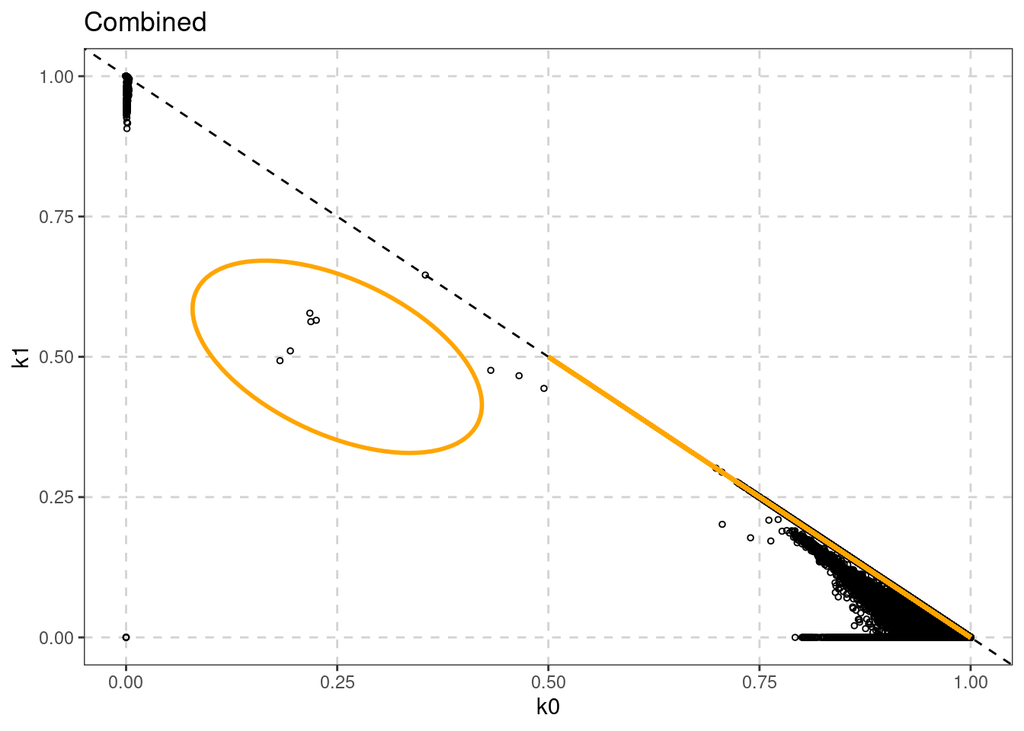

```r
ibd <- read.table("/projects/standard/basu_hbcd/shared/Documentation/relatedness.genome",
                  header=T)
library(ggplot2)
library(ellipse)
# Create ellipse data for half-sibling region
ell <- as.data.frame(ellipse(matrix(c(1, -0.5, -0.5, 1), 2, 2),
                              centre=c(0.25, 0.5),
                              scale=c(0.07, 0.07)))
colnames(ell) <- c("x", "y")

ggplot(ibd, aes(x=Z0, y=Z1)) +
  geom_point(shape=1, size=1) +
  geom_abline(intercept=1, slope=-1, linetype="dashed") +
  geom_path(data=ell, aes(x=x, y=y), color="orange", linewidth=1) +
  geom_segment(x=0.5, xend=1.0, y=0.5, yend=0.0, color="orange", linewidth=1) +
  xlim(0,1) + ylim(0,1) +
  labs(x="k0", y="k1", title="Combined") +
  theme_bw() +
  theme(panel.grid.major=element_line(color="lightgrey", linetype="dashed"),
        panel.grid.minor=element_blank())
```

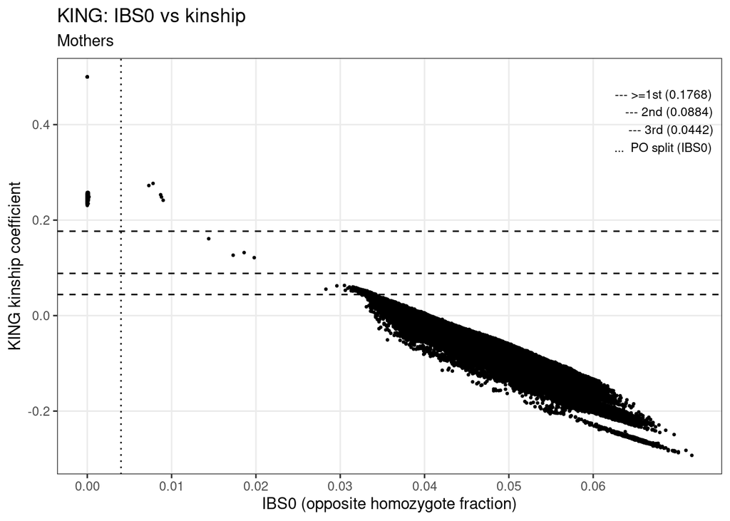

```r
kin <- read.table("/scratch.global/and02709/relatedness/kinships.kin", header=T)
kin0 <- read.table("/scratch.global/and02709/relatedness/kinships.kin0", header=T)

kin_all <- rbind(
  kin[, c("IBS0", "Kinship")],
  kin0[, c("IBS0", "Kinship")]
)

ggplot(kin_all, aes(x=IBS0, y=Kinship)) +
  geom_point(size=0.5) +
  geom_hline(yintercept=0.1768, linetype="dashed", linewidth=0.5) +
  geom_hline(yintercept=0.0884, linetype="dashed", linewidth=0.5) +
  geom_hline(yintercept=0.0442, linetype="dashed", linewidth=0.5) +
  geom_vline(xintercept=0.004, linetype="dotted", linewidth=0.5) +
  scale_x_continuous(breaks=seq(0, 0.06, by=0.01)) +
  labs(x="IBS0 (opposite homozygote fraction)",
       y="KING kinship coefficient",
       title="KING: IBS0 vs kinship",
       subtitle="Mothers") +
  annotate("text", x=Inf, y=Inf, hjust=1.1, vjust=1.5, size=3,
           label="--- >=1st (0.1768)\n--- 2nd (0.0884)\n--- 3rd (0.0442)\n...  PO split (IBS0)") +
  theme_bw() +
  theme(panel.grid.minor=element_blank(),
        plot.subtitle=element_text(hjust=0))
```

[figure not shown]

```r
kin_children <- rbind(
  kin[grep("C$", kin$ID1), c("IBS0", "Kinship")],
  kin0[grep("C$", kin0$ID1) & grep("C$", kin0$ID2), c("IBS0", "Kinship")]
)
ggplot(kin_children, aes(x=IBS0, y=Kinship)) +
  geom_point(size=0.5) +
  geom_hline(yintercept=0.1768, linetype="dashed", linewidth=0.5) +
  geom_hline(yintercept=0.0884, linetype="dashed", linewidth=0.5) +
  geom_hline(yintercept=0.0442, linetype="dashed", linewidth=0.5) +
  geom_vline(xintercept=0.004, linetype="dotted", linewidth=0.5) +
  scale_x_continuous(breaks=seq(0, 0.06, by=0.01)) +
  labs(x="IBS0 (opposite homozygote fraction)",
       y="KING kinship coefficient",
       title="KING: IBS0 vs kinship",
       subtitle="Children") +
  annotate("text", x=Inf, y=Inf, hjust=1.1, vjust=1.5, size=3,
           label="--- >=1st (0.1768)\n--- 2nd (0.0884)\n--- 3rd (0.0442)\n...  PO split (IBS0)") +
  theme_bw() +
  theme(panel.grid.minor=element_blank(),
        plot.subtitle=element_text(hjust=0))
```

## 4.2 Mother Child Analysis

```
[1] 402
```

```
   Min. 1st Qu.  Median    Mean 3rd Qu.    Max.
-0.0271  0.2479  0.2499  0.2455  0.2511  0.5000
```

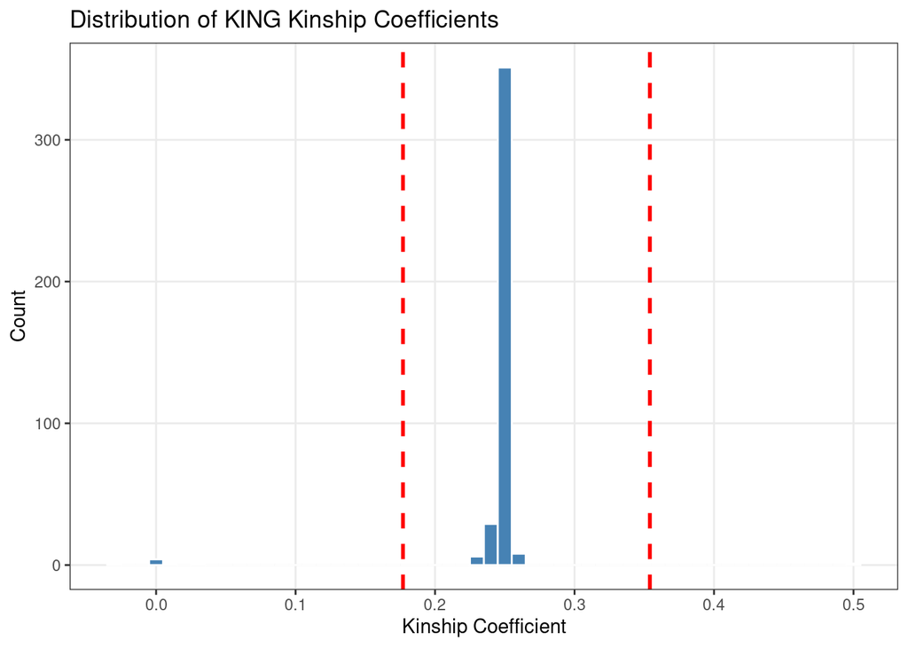

```r
kin_path <- "/scratch.global/and02709/relatedness/kinships.kin"

kin <- read.table(kin_path, header = TRUE) %>%
  filter(!grepl("^Positive_Control_", ID1)) %>%
  filter(!grepl("^Positive_Control_", ID2))

# Parse replicate letters and numeric IDs
kin$r1  <- substr(kin$ID1, nchar(kin$ID1), nchar(kin$ID1))
kin$r2  <- substr(kin$ID2, nchar(kin$ID2), nchar(kin$ID2))
kin$id1 <- substr(kin$ID1, 1, nchar(kin$ID1) - 1)
kin$id2 <- substr(kin$ID2, 1, nchar(kin$ID2) - 1)

# Filter to cross-replicate same-individual pairs
kin_mc <- kin %>% filter(id1 == id2, r1 != r2)

# Flag unexpected kinship (not ~0.25)
kin_mc_unrelated <- kin_mc %>%
  filter(Kinship < 0.18 | Kinship > 0.32) %>%
  select(ID1, ID2, r1, r2, Kinship) %>%
  arrange(Kinship)

kin_mc_unrelated %>%
  kable("html") %>%
  kable_styling(full_width = TRUE)
```

```r
kin_path <- "/scratch.global/and02709/relatedness/kinships.kin"

kin <- read.table(kin_path, header = TRUE) %>%
  filter(!grepl("^Positive_Control_", ID1)) %>%
  filter(!grepl("^Positive_Control_", ID2))

# Parse replicate letters and numeric IDs
kin$r1  <- substr(kin$ID1, nchar(kin$ID1), nchar(kin$ID1))
kin$r2  <- substr(kin$ID2, nchar(kin$ID2), nchar(kin$ID2))
kin$id1 <- substr(kin$ID1, 1, nchar(kin$ID1) - 1)
kin$id2 <- substr(kin$ID2, 1, nchar(kin$ID2) - 1)

# Filter to cross-replicate same-individual pairs
kin_mc <- kin %>% filter(id1 == id2, r1 != r2)

# Flag unexpected kinship (not ~0.25)
kin_mc_unrelated <- kin_mc %>%
  filter(Kinship < 0.18 | Kinship > 0.32) %>%
  select(ID1, ID2, r1, r2, Kinship) %>%
  arrange(Kinship)

# kin_mc_unrelated %>%
#   kable("html") %>%
#   kable_styling(full_width = TRUE)

kin_mc_unrelated %>%
  mutate(
    ID1 = paste0("XXXXXXXXXX", r1),
    ID2 = paste0("XXXXXXXXXX", r2)
  ) %>%
  kable("html") %>%
  kable_styling(full_width = TRUE)
```

| ID1 | ID2 | r1 | r2 | Kinship |
| --- | --- | --- | --- | --- |
| XXXXXXXXXXC | XXXXXXXXXXM | C | M | -0.0271 |
| XXXXXXXXXXC | XXXXXXXXXXM | C | M | -0.0021 |
| XXXXXXXXXXC | XXXXXXXXXXM | C | M | -0.0010 |
| XXXXXXXXXXC | XXXXXXXXXXM | C | M | 0.0012 |
| XXXXXXXXXXC | XXXXXXXXXXM | C | M | 0.0023 |
| XXXXXXXXXXC | XXXXXXXXXXM | C | M | 0.0056 |
| XXXXXXXXXXC | XXXXXXXXXXM | C | M | 0.0260 |
| XXXXXXXXXXC | XXXXXXXXXXM | C | M | 0.5000 |

I flagged first cousins between (0.06, 0.1)

I flagged Half siblings and Aunt/uncle-niece/nephew as (0.1, 0.18)

I flagged close relationships as any non mother-child pairs greater than 0.18

## 4.3 Cryptic relatedness

```r
kin_path <- "/scratch.global/and02709/relatedness/kinships.kin0"
kin <- read.table(kin_path, header = TRUE, stringsAsFactors = FALSE) %>%
  filter(!grepl("^Positive_Control_", ID1)) %>%
  filter(!grepl("^Positive_Control_", ID2))

# Parse replicate letters and numeric IDs
kin$r1  <- substr(kin$ID1, nchar(kin$ID1), nchar(kin$ID1))
kin$r2  <- substr(kin$ID2, nchar(kin$ID2), nchar(kin$ID2))
kin$id1 <- substr(kin$ID1, 1, nchar(kin$ID1) - 1)
kin$id2 <- substr(kin$ID2, 1, nchar(kin$ID2) - 1)

# Filter to cross-replicate same-individual pairs
kin_mc <- kin %>% filter(id1 == id2, r1 != r2)

# Remove same-individual pairs, keep only between-individual pairs
kinf <- anti_join(kin, kin_mc)

# Flag related pairs (kinship > 0.0625 = beyond 3rd degree)
kinf_related <- kinf %>%
  filter(Kinship > 0.06) %>%
  dplyr::select(-c(FID1, FID2, r1, r2, id1, id2))
```

| ID1 | ID2 | N_SNP | HetHet | IBS0 | Kinship |
| --- | --- | --- | --- | --- | --- |
| XXXXXXXXXX | XXXXXXXXXX | 856142 | 0.1162 | 0.0001 | 0.2504 |
| XXXXXXXXXX | XXXXXXXXXX | 856595 | 0.0921 | 0.0198 | 0.1214 |
| XXXXXXXXXX | XXXXXXXXXX | 856933 | 0.0902 | 0.0315 | 0.0601 |
| XXXXXXXXXX | XXXXXXXXXX | 855393 | 0.0900 | 0.0305 | 0.0632 |
| XXXXXXXXXX | XXXXXXXXXX | 855932 | 0.1203 | 0.0001 | 0.2491 |
| XXXXXXXXXX | XXXXXXXXXX | 856795 | 0.2413 | 0.0000 | 0.5000 |
| XXXXXXXXXX | XXXXXXXXXX | 854520 | 0.1065 | 0.0000 | 0.2496 |
| XXXXXXXXXX | XXXXXXXXXX | 857013 | 0.0900 | 0.0173 | 0.1265 |
| XXXXXXXXXX | XXXXXXXXXX | 856165 | 0.1039 | 0.0144 | 0.1611 |
| XXXXXXXXXX | XXXXXXXXXX | 855836 | 0.1144 | 0.0001 | 0.2513 |
| XXXXXXXXXX | XXXXXXXXXX | 855928 | 0.2275 | 0.0000 | 0.5000 |
| XXXXXXXXXX | XXXXXXXXXX | 856831 | 0.0869 | 0.0296 | 0.0624 |
| XXXXXXXXXX | XXXXXXXXXX | 856535 | 0.1112 | 0.0001 | 0.2492 |
| XXXXXXXXXX | XXXXXXXXXX | 855820 | 0.1354 | 0.0087 | 0.2532 |
| XXXXXXXXXX | XXXXXXXXXX | 856599 | 0.1202 | 0.0001 | 0.2487 |
| XXXXXXXXXX | XXXXXXXXXX | 857046 | 0.2169 | 0.0000 | 0.5000 |
| XXXXXXXXXX | XXXXXXXXXX | 856678 | 0.1300 | 0.0088 | 0.2484 |
| XXXXXXXXXX | XXXXXXXXXX | 856654 | 0.1140 | 0.0001 | 0.2495 |
| XXXXXXXXXX | XXXXXXXXXX | 855733 | 0.1430 | 0.0078 | 0.2769 |
| XXXXXXXXXX | XXXXXXXXXX | 856827 | 0.0942 | 0.0186 | 0.1320 |
| XXXXXXXXXX | XXXXXXXXXX | 856851 | 0.1317 | 0.0073 | 0.2725 |
| XXXXXXXXXX | XXXXXXXXXX | 853013 | 0.1256 | 0.0090 | 0.2416 |

### 4.3.1 First Cousins

```r
kin_path <- "/scratch.global/and02709/relatedness/kinships.kin0"
kin <- read.table(kin_path, header = TRUE, stringsAsFactors = FALSE) %>%
  filter(!grepl("^Positive_Control_", ID1)) %>%
  filter(!grepl("^Positive_Control_", ID2))

# Parse replicate letters and numeric IDs
kin$r1  <- substr(kin$ID1, nchar(kin$ID1), nchar(kin$ID1))
kin$r2  <- substr(kin$ID2, nchar(kin$ID2), nchar(kin$ID2))
kin$id1 <- substr(kin$ID1, 1, nchar(kin$ID1) - 1)
kin$id2 <- substr(kin$ID2, 1, nchar(kin$ID2) - 1)

# Filter to cross-replicate same-individual pairs
kin_mc <- kin %>% filter(id1 == id2, r1 != r2)

# Remove same-individual pairs, keep only between-individual pairs
kinf <- anti_join(kin, kin_mc)

# Flag related pairs (kinship > 0.0625 = beyond 3rd degree)
kinf_related <- kinf %>%
  filter(Kinship > 0.06) %>%
  dplyr::select(-c(FID1, FID2, r1, r2, id1, id2))

kinf_related %>%
  kable("html") %>%
  kable_styling(full_width = TRUE)
```

| ID1 | ID2 | N_SNP | HetHet | IBS0 | Kinship |
| --- | --- | --- | --- | --- | --- |
| XXXXXXXXXX | XXXXXXXXXX | 856142 | 0.1162 | 0.0001 | 0.2504 |
| XXXXXXXXXX | XXXXXXXXXX | 856595 | 0.0921 | 0.0198 | 0.1214 |
| XXXXXXXXXX | XXXXXXXXXX | 856933 | 0.0902 | 0.0315 | 0.0601 |
| XXXXXXXXXX | XXXXXXXXXX | 855393 | 0.0900 | 0.0305 | 0.0632 |
| XXXXXXXXXX | XXXXXXXXXX | 855932 | 0.1203 | 0.0001 | 0.2491 |
| XXXXXXXXXX | XXXXXXXXXX | 856795 | 0.2413 | 0.0000 | 0.5000 |
| XXXXXXXXXX | XXXXXXXXXX | 854520 | 0.1065 | 0.0000 | 0.2496 |
| XXXXXXXXXX | XXXXXXXXXX | 857013 | 0.0900 | 0.0173 | 0.1265 |
| XXXXXXXXXX | XXXXXXXXXX | 856165 | 0.1039 | 0.0144 | 0.1611 |
| XXXXXXXXXX | XXXXXXXXXX | 855836 | 0.1144 | 0.0001 | 0.2513 |
| XXXXXXXXXX | XXXXXXXXXX | 855928 | 0.2275 | 0.0000 | 0.5000 |
| XXXXXXXXXX | XXXXXXXXXX | 856831 | 0.0869 | 0.0296 | 0.0624 |
| XXXXXXXXXX | XXXXXXXXXX | 856535 | 0.1112 | 0.0001 | 0.2492 |
| XXXXXXXXXX | XXXXXXXXXX | 855820 | 0.1354 | 0.0087 | 0.2532 |
| XXXXXXXXXX | XXXXXXXXXX | 856599 | 0.1202 | 0.0001 | 0.2487 |
| XXXXXXXXXX | XXXXXXXXXX | 857046 | 0.2169 | 0.0000 | 0.5000 |
| XXXXXXXXXX | XXXXXXXXXX | 856678 | 0.1300 | 0.0088 | 0.2484 |
| XXXXXXXXXX | XXXXXXXXXX | 856654 | 0.1140 | 0.0001 | 0.2495 |
| XXXXXXXXXX | XXXXXXXXXX | 855733 | 0.1430 | 0.0078 | 0.2769 |
| XXXXXXXXXX | XXXXXXXXXX | 856827 | 0.0942 | 0.0186 | 0.1320 |
| XXXXXXXXXX | XXXXXXXXXX | 856851 | 0.1317 | 0.0073 | 0.2725 |
| XXXXXXXXXX | XXXXXXXXXX | 853013 | 0.1256 | 0.0090 | 0.2416 |

### 4.3.2 Aunt Uncle

```r
kin_path <- "/scratch.global/and02709/relatedness/kinships.kin0"
kin <- read.table(kin_path, header = TRUE, stringsAsFactors = FALSE) %>%
  filter(!grepl("^Positive_Control_", ID1)) %>%
  filter(!grepl("^Positive_Control_", ID2))
# Parse replicate letters and numeric IDs
kin$r1  <- substr(kin$ID1, nchar(kin$ID1), nchar(kin$ID1))
kin$r2  <- substr(kin$ID2, nchar(kin$ID2), nchar(kin$ID2))
kin$id1 <- substr(kin$ID1, 1, nchar(kin$ID1) - 1)
kin$id2 <- substr(kin$ID2, 1, nchar(kin$ID2) - 1)
# Filter to cross-replicate same-individual pairs
kin_mc <- kin %>% filter(id1 == id2, r1 != r2)
# Remove same-individual pairs, keep only between-individual pairs
kinf <- anti_join(kin, kin_mc)
# Flag aunt/uncle relationships (kinship 0.1 - 0.18)
kinf_auhalf <- kinf %>%
  filter(Kinship > 0.1, Kinship < 0.18) %>%
  dplyr::select(-c(FID1, FID2, r1, r2, id1, id2))
```

| ID1 | ID2 | N_SNP | HetHet | IBS0 | Kinship |
| --- | --- | --- | --- | --- | --- |
| XXXXXXXXXX | XXXXXXXXXX | 856595 | 0.0921 | 0.0198 | 0.1214 |
| XXXXXXXXXX | XXXXXXXXXX | 857013 | 0.0900 | 0.0173 | 0.1265 |
| XXXXXXXXXX | XXXXXXXXXX | 856165 | 0.1039 | 0.0144 | 0.1611 |
| XXXXXXXXXX | XXXXXXXXXX | 856827 | 0.0942 | 0.0186 | 0.1320 |

### 4.3.3 Cryptic Close Relationship

```r
kin_path <- "/scratch.global/and02709/relatedness/kinships.kin0"
kin <- read.table(kin_path, header = TRUE, stringsAsFactors = FALSE) %>%
  filter(!grepl("^Positive_Control_", ID1)) %>%
  filter(!grepl("^Positive_Control_", ID2))
# Parse replicate letters and numeric IDs
kin$r1  <- substr(kin$ID1, nchar(kin$ID1), nchar(kin$ID1))
kin$r2  <- substr(kin$ID2, nchar(kin$ID2), nchar(kin$ID2))
kin$id1 <- substr(kin$ID1, 1, nchar(kin$ID1) - 1)
kin$id2 <- substr(kin$ID2, 1, nchar(kin$ID2) - 1)
# Filter to cross-replicate same-individual pairs
kin_mc <- kin %>% filter(id1 == id2, r1 != r2)
# Remove same-individual pairs, keep only between-individual pairs
kinf <- anti_join(kin, kin_mc)
# Flag cryptic close relationships (kinship > 0.18)
kinf_close <- kinf %>%
  filter(Kinship > 0.18) %>%
  dplyr::select(-c(FID1, FID2, r1, r2, id1, id2))
```

| ID1 | ID2 | N_SNP | HetHet | IBS0 | Kinship |
| --- | --- | --- | --- | --- | --- |
| XXXXXXXXXX | XXXXXXXXXX | 856142 | 0.1162 | 0.0001 | 0.2504 |
| XXXXXXXXXX | XXXXXXXXXX | 855932 | 0.1203 | 0.0001 | 0.2491 |
| XXXXXXXXXX | XXXXXXXXXX | 856795 | 0.2413 | 0.0000 | 0.5000 |
| XXXXXXXXXX | XXXXXXXXXX | 854520 | 0.1065 | 0.0000 | 0.2496 |
| XXXXXXXXXX | XXXXXXXXXX | 855836 | 0.1144 | 0.0001 | 0.2513 |
| XXXXXXXXXX | XXXXXXXXXX | 855928 | 0.2275 | 0.0000 | 0.5000 |
| XXXXXXXXXX | XXXXXXXXXX | 856535 | 0.1112 | 0.0001 | 0.2492 |
| XXXXXXXXXX | XXXXXXXXXX | 855820 | 0.1354 | 0.0087 | 0.2532 |
| XXXXXXXXXX | XXXXXXXXXX | 856599 | 0.1202 | 0.0001 | 0.2487 |
| XXXXXXXXXX | XXXXXXXXXX | 857046 | 0.2169 | 0.0000 | 0.5000 |
| XXXXXXXXXX | XXXXXXXXXX | 856678 | 0.1300 | 0.0088 | 0.2484 |
| XXXXXXXXXX | XXXXXXXXXX | 856654 | 0.1140 | 0.0001 | 0.2495 |
| XXXXXXXXXX | XXXXXXXXXX | 855733 | 0.1430 | 0.0078 | 0.2769 |
| XXXXXXXXXX | XXXXXXXXXX | 856851 | 0.1317 | 0.0073 | 0.2725 |
| XXXXXXXXXX | XXXXXXXXXX | 853013 | 0.1256 | 0.0090 | 0.2416 |

# 4.3.3 Clusters

```r
# Load fam file
# Load fam file
fam <- read.table(
  "/projects/standard/basu_hbcd/shared/HST_HBCD_Transfer_July2025/HBCD/HBCD.fam",
  header = FALSE
)
colnames(fam) <- c("FID", "IID", "MID", "PID", "Sex", "Phenotype")

# Extract numeric id and replicate letter from IID
fam$PSCID        <- sub(".*_", "", fam$IID)
fam$id           <- substr(fam$PSCID, 1, nchar(fam$PSCID) - 1)
fam$relationship <- substr(fam$PSCID, nchar(fam$PSCID), nchar(fam$PSCID))

# Load demo file - extracting just the tail fields
lines <- readLines(
  "/projects/standard/basu_hbcd/shared/HST_HBCD_Transfer_July2025/Demo_files/demo_appended_IID.txt"
)
tail_fields <- lapply(lines, function(x) {
  parts <- unlist(strsplit(trimws(x), "\\s+"))
  tail(parts, 6)
})
demo_fam <- as.data.frame(do.call(rbind, tail_fields), stringsAsFactors = FALSE)
colnames(demo_fam) <- c("FID", "IID", "MID", "PID", "Sex", "Status")
demo_fam <- demo_fam[-1, ]

# Extract id and relationship from demo IID for joining
demo_fam$PSCID        <- sub(".*_", "", demo_fam$IID)
demo_fam$id           <- substr(demo_fam$PSCID, 1, nchar(demo_fam$PSCID) - 1)
demo_fam$relationship <- substr(demo_fam$PSCID, nchar(demo_fam$PSCID), nchar(demo_fam$PSCID))
demo_fam$demo_sex     <- demo_fam$Sex

# Load sex check file
sexcheck <- read.table(
  "/projects/standard/basu_hbcd/shared/Documentation/sex_check.sexcheck",
  header = TRUE
)

# Join everything
data <- inner_join(sexcheck, fam, by = c("FID", "IID")) %>%
  inner_join(demo_fam[, c("id", "relationship", "demo_sex")],
             by = c("id", "relationship"))

# Rename columns
colnames(data)[colnames(data) == "Sex"]    <- "ped_sex"
colnames(data)[colnames(data) == "PEDSEX"] <- "plink_ped_sex"
colnames(data)[colnames(data) == "SNPSEX"] <- "plink_sex"

# Extract plink update
plink_update <- data %>% dplyr::select(FID, IID, plink_sex)

# Display redacted table (first 30 rows)
data %>%
  head(30) %>%
  select(FID, IID, plink_ped_sex, plink_sex, STATUS, F) %>%
  mutate(FID = "XXXXXXXXXX", IID = "XXXXXXXXXX") %>%
  kable("html") %>%
  kable_styling(full_width = TRUE)
```

| FID | IID | plink_ped_sex | plink_sex | STATUS | F |
| --- | --- | --- | --- | --- | --- |
| XXXXXXXXXX | XXXXXXXXXX | 2 | 2 | OK | -0.06878 |
| XXXXXXXXXX | XXXXXXXXXX | 2 | 2 | OK | -0.11290 |
| XXXXXXXXXX | XXXXXXXXXX | 2 | 2 | OK | 0.07108 |
| XXXXXXXXXX | XXXXXXXXXX | 2 | 2 | OK | 0.04964 |
| XXXXXXXXXX | XXXXXXXXXX | 2 | 2 | OK | 0.12680 |
| XXXXXXXXXX | XXXXXXXXXX | 2 | 2 | OK | 0.17440 |
| XXXXXXXXXX | XXXXXXXXXX | 2 | 2 | OK | 0.21610 |
| XXXXXXXXXX | XXXXXXXXXX | 2 | 2 | OK | 0.12250 |
| XXXXXXXXXX | XXXXXXXXXX | 2 | 2 | OK | 0.13130 |
| XXXXXXXXXX | XXXXXXXXXX | 2 | 2 | OK | 0.14240 |
| XXXXXXXXXX | XXXXXXXXXX | 2 | 2 | OK | 0.13190 |
| XXXXXXXXXX | XXXXXXXXXX | 2 | 2 | OK | -0.10580 |
| XXXXXXXXXX | XXXXXXXXXX | 2 | 2 | OK | -0.05209 |
| XXXXXXXXXX | XXXXXXXXXX | 2 | 2 | OK | 0.16260 |
| XXXXXXXXXX | XXXXXXXXXX | 2 | 2 | OK | 0.18910 |
| XXXXXXXXXX | XXXXXXXXXX | 2 | 2 | OK | 0.16940 |
| XXXXXXXXXX | XXXXXXXXXX | 2 | 2 | OK | 0.13900 |
| XXXXXXXXXX | XXXXXXXXXX | 2 | 2 | OK | 0.24570 |
| XXXXXXXXXX | XXXXXXXXXX | 2 | 2 | OK | 0.02507 |
| XXXXXXXXXX | XXXXXXXXXX | 2 | 2 | OK | -0.15070 |
| XXXXXXXXXX | XXXXXXXXXX | 2 | 2 | OK | 0.15970 |
| XXXXXXXXXX | XXXXXXXXXX | 2 | 2 | OK | 0.17920 |
| XXXXXXXXXX | XXXXXXXXXX | 2 | 2 | OK | 0.16930 |
| XXXXXXXXXX | XXXXXXXXXX | 2 | 2 | OK | 0.14920 |
| XXXXXXXXXX | XXXXXXXXXX | 2 | 2 | OK | -0.09469 |
| XXXXXXXXXX | XXXXXXXXXX | 2 | 2 | OK | -0.01245 |
| XXXXXXXXXX | XXXXXXXXXX | 2 | 2 | OK | 0.01294 |
| XXXXXXXXXX | XXXXXXXXXX | 2 | 2 | OK | 0.12660 |
| XXXXXXXXXX | XXXXXXXXXX | 2 | 2 | OK | 0.14020 |
| XXXXXXXXXX | XXXXXXXXXX | 2 | 2 | OK | 0.18130 |

```r
kin_path <- "/scratch.global/and02709/relatedness/kinships.kin0"
kin <- read.table(kin_path, header = TRUE, stringsAsFactors = FALSE) %>%
  filter(!grepl("^Positive_Control_", ID1)) %>%
  filter(!grepl("^Positive_Control_", ID2))

# Parse replicate letters and numeric IDs
kin$r1  <- substr(kin$ID1, nchar(kin$ID1), nchar(kin$ID1))
kin$r2  <- substr(kin$ID2, nchar(kin$ID2), nchar(kin$ID2))
kin$id1 <- substr(kin$ID1, 1, nchar(kin$ID1) - 1)
kin$id2 <- substr(kin$ID2, 1, nchar(kin$ID2) - 1)

# Remove same-individual cross-replicate pairs
kin_mc <- kin %>% filter(id1 == id2, r1 != r2)
kinf <- anti_join(kin, kin_mc)

# Flag cryptic close relationships (kinship > 0.18)
dataClose <- kinf %>%
  head(30) %>%
  filter(Kinship > 0.18) %>%
  select(ID1, ID2, Kinship) %>%
  arrange(desc(Kinship))
```

[output not shown]

| ID1 | ID2 | Kinship |
| --- | --- | --- |
| XXXXXXXXXX | XXXXXXXXXX | 0.5000 |
| XXXXXXXXXX | XXXXXXXXXX | 0.5000 |
| XXXXXXXXXX | XXXXXXXXXX | 0.5000 |
| XXXXXXXXXX | XXXXXXXXXX | 0.2769 |
| XXXXXXXXXX | XXXXXXXXXX | 0.2725 |
| XXXXXXXXXX | XXXXXXXXXX | 0.2532 |
| XXXXXXXXXX | XXXXXXXXXX | 0.2513 |
| XXXXXXXXXX | XXXXXXXXXX | 0.2504 |
| XXXXXXXXXX | XXXXXXXXXX | 0.2496 |
| XXXXXXXXXX | XXXXXXXXXX | 0.2495 |
| XXXXXXXXXX | XXXXXXXXXX | 0.2492 |
| XXXXXXXXXX | XXXXXXXXXX | 0.2491 |
| XXXXXXXXXX | XXXXXXXXXX | 0.2487 |
| XXXXXXXXXX | XXXXXXXXXX | 0.2484 |
| XXXXXXXXXX | XXXXXXXXXX | 0.2416 |

```r
kin_mc_unrelated %>%
  head(30) %>%
  mutate(ID1 = "XXXXXXXXXX", ID2 = "XXXXXXXXXX") %>%
  kable("html") %>%
  kable_styling(full_width = TRUE)
```

| ID1 | ID2 | r1 | r2 | Kinship |
| --- | --- | --- | --- | --- |
| XXXXXXXXXX | XXXXXXXXXX | C | M | -0.0271 |
| XXXXXXXXXX | XXXXXXXXXX | C | M | -0.0021 |
| XXXXXXXXXX | XXXXXXXXXX | C | M | -0.0010 |
| XXXXXXXXXX | XXXXXXXXXX | C | M | 0.0012 |
| XXXXXXXXXX | XXXXXXXXXX | C | M | 0.0023 |
| XXXXXXXXXX | XXXXXXXXXX | C | M | 0.0056 |
| XXXXXXXXXX | XXXXXXXXXX | C | M | 0.0260 |
| XXXXXXXXXX | XXXXXXXXXX | C | M | 0.5000 |

## 5.1 Relationship Clusters

```r
suppressPackageStartupMessages({
  library(readr)
  library(dplyr)
  library(igraph)
  library(knitr)
  library(kableExtra)
})

# Read kinship file
kin_path <- "/scratch.global/and02709/relatedness/kinships.kin0"
kin <- read_tsv(kin_path, comment = "#", show_col_types = FALSE)

# Filter positive controls
kin <- kin %>%
  filter(!grepl("^Positive_Control_", ID1)) %>%
  filter(!grepl("^Positive_Control_", ID2))

# Parse replicate letters and numeric IDs
kin$r1  <- substr(kin$ID1, nchar(kin$ID1), nchar(kin$ID1))
kin$r2  <- substr(kin$ID2, nchar(kin$ID2), nchar(kin$ID2))
kin$id1 <- substr(kin$ID1, 1, nchar(kin$ID1) - 1)
kin$id2 <- substr(kin$ID2, 1, nchar(kin$ID2) - 1)

# Remove same-individual cross-replicate pairs
kin_mc <- kin %>% filter(id1 == id2, r1 != r2)
kinf <- anti_join(kin, kin_mc)

# Classify relationship types
kinf <- kinf %>%
  mutate(rel = case_when(
    Kinship > 0.354                   ~ "Dup/MZ",
    Kinship >= 0.177 & IBS0 <  0.001 ~ "PO",
    Kinship >= 0.177 & IBS0 >= 0.001 ~ "FS",
    Kinship >= 0.0884                 ~ "2nd",
    Kinship >= 0.0442                 ~ "3rd",
    TRUE                              ~ "Unrel"
  ))

# Build edges for related pairs only
edges <- kinf %>%
  filter(rel %in% c("Dup/MZ", "PO", "FS", "2nd")) %>%
  transmute(from = ID1, to = ID2, rel)

# Build graph and find connected components (family clusters)
g <- graph_from_data_frame(edges, directed = FALSE)
comp <- components(g)

clusters <- split(V(g)$name, comp$membership)
sizes    <- sapply(clusters, length)

# Largest cluster
ids_largest <- clusters[[which.max(sizes)]]
cat("Largest cluster size:", max(sizes), "\n")
```

```
Largest cluster size: 4
```

```r
cat("Number of clusters:", length(clusters), "\n")
```

```
Number of clusters: 10
```

```r
cat("Dyads (size == 2):", sum(sizes == 2), "\n")
```

```
Dyads (size == 2): 5
```

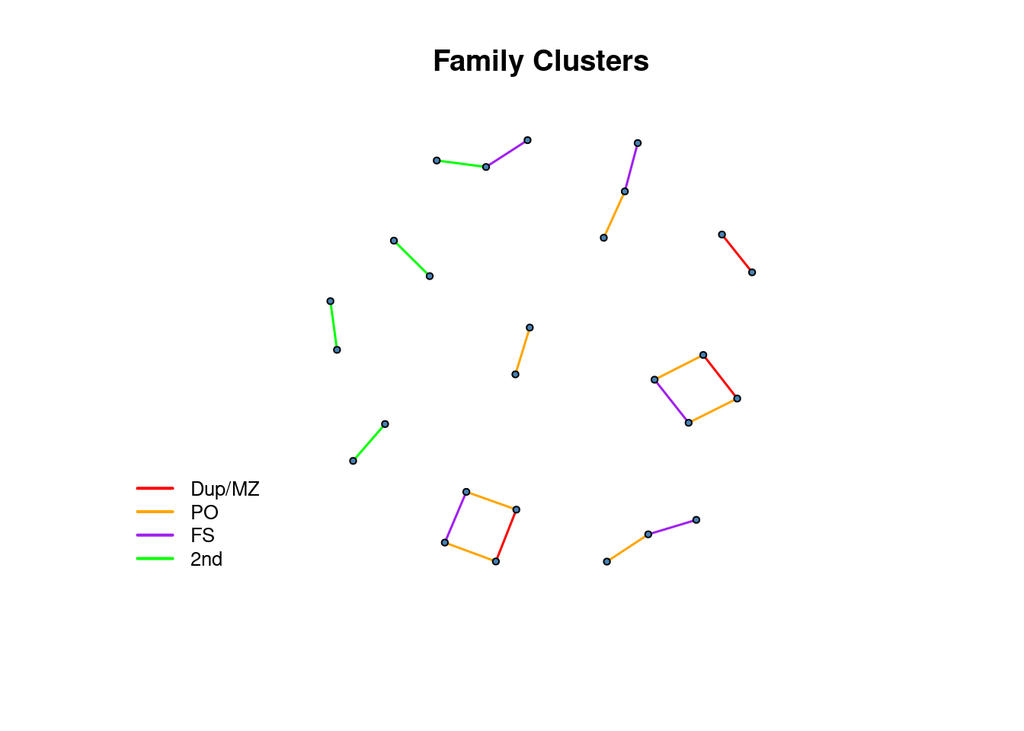

```r
# Write cluster membership table
iid2cluster <- data.frame(
  IID          = V(g)$name,
  cluster_id   = comp$membership,
  cluster_size = sizes[as.character(comp$membership)],
  stringsAsFactors = FALSE
)
write.csv(iid2cluster,
          "/scratch.global/and02709/relatedness/iid_cluster_map.csv",
          row.names = FALSE)

# Set vertex and edge aesthetics
V(g)$color <- "steelblue"
V(g)$size  <- 3
V(g)$label <- NA

E(g)$color <- case_when(
  E(g)$rel == "Dup/MZ" ~ "red",
  E(g)$rel == "PO"     ~ "orange",
  E(g)$rel == "FS"     ~ "purple",
  E(g)$rel == "2nd"    ~ "green",
  TRUE                  ~ "grey"
)

# Plot
plot(g,
     layout       = layout_with_fr(g),
     vertex.size  = 3,
     vertex.label = NA,
     edge.width   = 1.5,
     main         = "Family Clusters",
     margin       = 0)

legend("bottomleft",
       legend = c("Dup/MZ", "PO", "FS", "2nd"),
       col    = c("red", "orange", "purple", "green"),
       lwd    = 2,
       bty    = "n",
       cex    = 0.8)
```

```r
# Display redacted cluster table (clusters > 2 members)
iid2cluster %>%
  filter(cluster_size > 2) %>%
  filter(!grepl("Positive_Control", IID)) %>%
  arrange(cluster_id) %>%
  head(30) %>%
  mutate(IID = "XXXXXXXXXX") %>%
  `rownames<-`(NULL) %>%
  kable("html", row.names = FALSE) %>%
  kable_styling(full_width = TRUE)
```

| IID | cluster_id | cluster_size |
| --- | --- | --- |
| XXXXXXXXXX | 1 | 3 |
| XXXXXXXXXX | 1 | 3 |
| XXXXXXXXXX | 1 | 3 |
| XXXXXXXXXX | 3 | 4 |
| XXXXXXXXXX | 3 | 4 |
| XXXXXXXXXX | 3 | 4 |
| XXXXXXXXXX | 3 | 4 |
| XXXXXXXXXX | 7 | 4 |
| XXXXXXXXXX | 7 | 4 |
| XXXXXXXXXX | 7 | 4 |
| XXXXXXXXXX | 7 | 4 |
| XXXXXXXXXX | 8 | 3 |
| XXXXXXXXXX | 8 | 3 |
| XXXXXXXXXX | 8 | 3 |
| XXXXXXXXXX | 10 | 3 |
| XXXXXXXXXX | 10 | 3 |
| XXXXXXXXXX | 10 | 3 |

## 6.1 PCA Plots

First we need to run plink to get the eigenvectors.

```r
plink2 \
  --bfile /projects/standard/basu_hbcd/shared/HST_HBCD_Transfer_July2025/HBCD/HBCD \
  --pca 10 \
  --out /scratch.global/and02709/pca/HBCD_pca
```

```r
suppressPackageStartupMessages({
  library(dplyr)
  library(ggplot2)
  library(readr)
})

# ===================== CONFIG =====================
eigenvec_file <- "/scratch.global/and02709/pca/HBCD_pca.eigenvec"
eigenval_file <- "/scratch.global/and02709/pca/HBCD_pca.eigenval"
demo_file     <- "/projects/standard/basu_hbcd/shared/HST_HBCD_Transfer_July2025/Demo_files/demo_appended_IID.txt"
n_pcs         <- 10
out_dir       <- "/scratch.global/and02709/pca/plots"
# ===================================================

dir.create(out_dir, showWarnings = FALSE, recursive = TRUE)

# ---------- 1) Read PCA results ----------
pca <- read.table(eigenvec_file, header = FALSE)
pca <- pca[, 1:(n_pcs + 2)]
colnames(pca) <- c("FID", "IID", paste0("PC", 1:n_pcs))
pca$PSCID <- sub(".*_", "", pca$IID)

# ---------- 2) Extract PSCID and race from demo file ----------
lines <- readLines(demo_file)

# Race values to match (excludes ethnicity)
race_values <- c("white", "white_multi", "black_or_african_american",
                 "black_or_african_american_multi", "asian", "asian_multi",
                 "american_indian_or_alaskan_native_multi", "other_race",
                 "other_race_multi", "two_or_more_races")
race_pattern <- paste0("\\b(", paste(race_values, collapse = "|"), ")\\b")

demo_iid_race <- lapply(lines[-1], function(x) {
  parts    <- unlist(strsplit(trimws(x), "\\s+"))
  full_iid <- if (length(parts) >= 5) parts[length(parts) - 4] else NA_character_
  pscid    <- sub(".*_", "", full_iid)

  # Extract first race match
  matches <- regmatches(x, gregexpr(race_pattern, x, perl = TRUE))[[1]]
  race    <- if (length(matches) > 0) matches[1] else NA_character_

  data.frame(PSCID = pscid, race = race, stringsAsFactors = FALSE)
})

demo_iid_race <- do.call(rbind, demo_iid_race)

cat("Matched:", sum(pca$PSCID %in% demo_iid_race$PSCID), "of", nrow(pca), "\n")
```

```
Matched: 1270 of 1753
```

```r
cat("Unique race values:\n")
```

```
Unique race values:
```

```r
print(table(demo_iid_race$race, useNA = "ifany"))
```

```
american_indian_or_alaskan_native_multi                                   asian
                                     12                                      66
              black_or_african_american                              other_race
                                    302                                      84
                      two_or_more_races                                   white
                                     82                                     693
                                   <NA>
                                     31
```

```r
# ---------- 3) Join PCA with race ----------
pca <- pca %>%
  left_join(demo_iid_race, by = "PSCID")

cat("PCA rows with race:", sum(!is.na(pca$race)), "of", nrow(pca), "\n")
```

```
PCA rows with race: 1239 of 1753
```

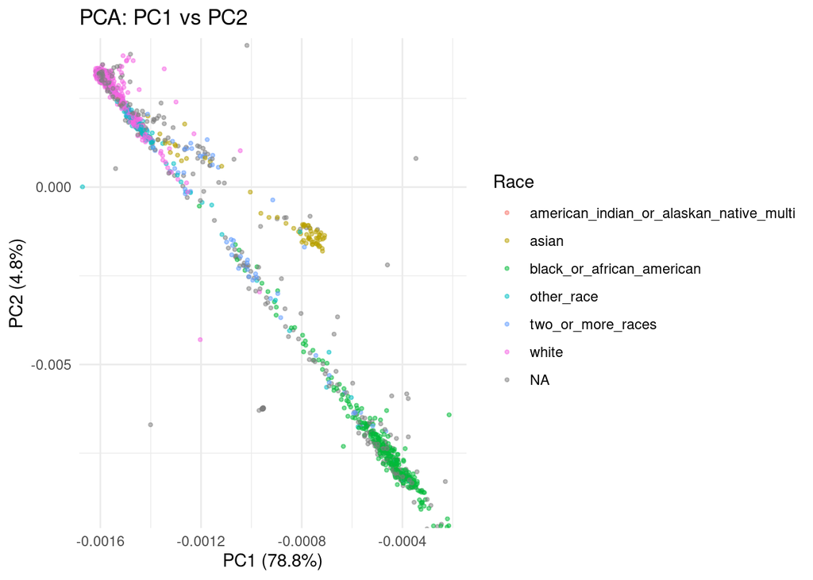

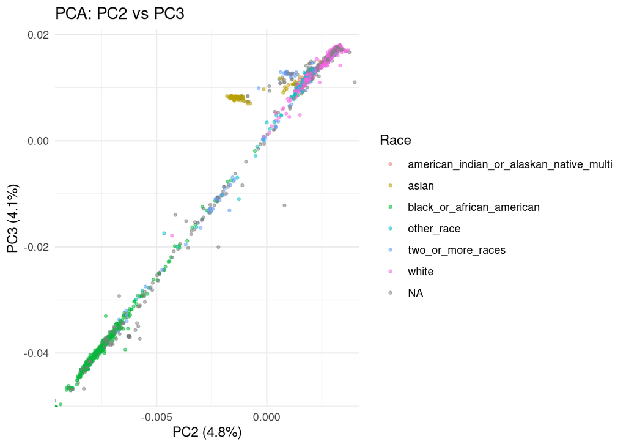

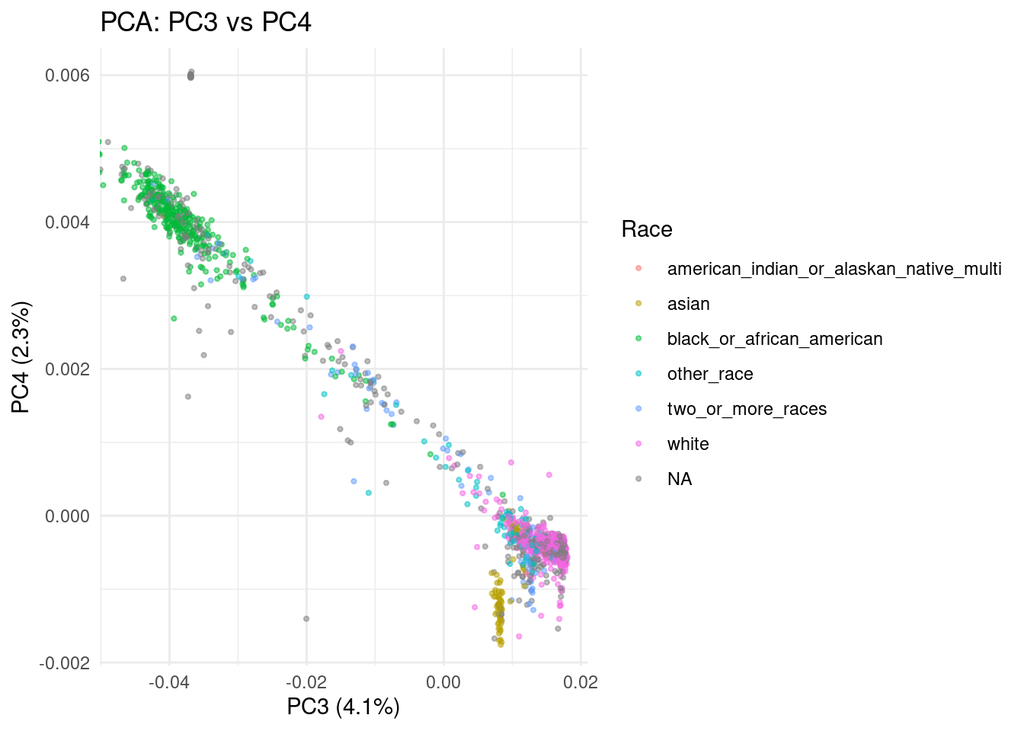

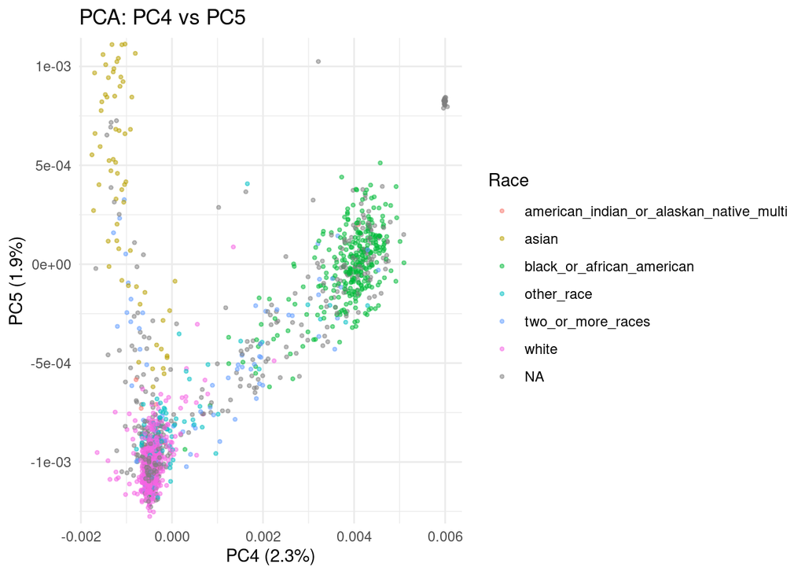

```r
# ---------- 4) Read eigenvalues ----------
eigenval <- read.table(eigenval_file, header = FALSE)
pct <- round(eigenval$V1 / sum(eigenval$V1) * 100, 1)

# ---------- 5) Plot PC pairs colored by race ----------
pc_pairs <- list(c(1, 2), c(2, 3), c(3, 4), c(4, 5))

plots <- lapply(pc_pairs, function(pair) {
  pcx <- paste0("PC", pair[1])
  pcy <- paste0("PC", pair[2])

  # Calculate limits excluding extreme outliers (1st-99th percentile)
  xlim <- quantile(pca[[pcx]], c(0.01, 0.99), na.rm = TRUE)
  ylim <- quantile(pca[[pcy]], c(0.01, 0.99), na.rm = TRUE)

  ggplot(pca, aes(x = .data[[pcx]], y = .data[[pcy]], color = race)) +
    geom_point(alpha = 0.5, size = 0.8) +
    coord_cartesian(xlim = xlim, ylim = ylim) +
    labs(
      title = paste0("PCA: ", pcx, " vs ", pcy),
      x     = paste0(pcx, " (", pct[pair[1]], "%)"),
      y     = paste0(pcy, " (", pct[pair[2]], "%)"),
      color = "Race"
    ) +
    theme_minimal(base_size = 11) +
    theme(legend.position = "right")
})

# ---------- 6) Display plots ----------
for (p in plots) print(p)
```

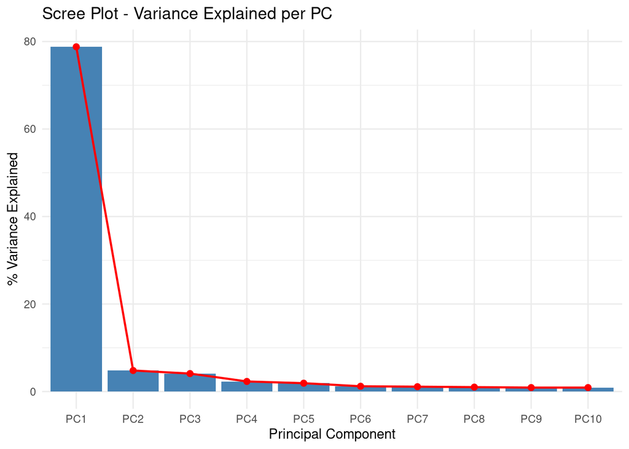

```r
# ---------- 7) Save plots to PNG ----------
for (i in seq_along(pc_pairs)) {
  pair <- pc_pairs[[i]]
  png_file <- file.path(out_dir,
                        sprintf("PCA_PC%d_vs_PC%d.png", pair[1], pair[2]))
  ggsave(png_file, plot = plots[[i]],
         width = 8, height = 6, dpi = 200)
  message("Saved: ", png_file)
}

# ---------- 8) Scree plot ----------
scree_df <- data.frame(
  PC  = factor(paste0("PC", 1:n_pcs), levels = paste0("PC", 1:n_pcs)),
  Pct = pct[1:n_pcs]
)

scree <- ggplot(scree_df, aes(x = PC, y = Pct)) +
  geom_col(fill = "steelblue") +
  geom_line(aes(group = 1), color = "red", linewidth = 0.8) +
  geom_point(color = "red", size = 2) +
  labs(
    title = "Scree Plot - Variance Explained per PC",
    x     = "Principal Component",
    y     = "% Variance Explained"
  ) +
  theme_minimal(base_size = 11)

print(scree)
```

```r
ggsave(file.path(out_dir, "scree_plot.png"),
       plot = scree, width = 8, height = 5, dpi = 200)

message("All plots saved to: ", out_dir)
```